# Incorporating Measurement Error in Continuous Trait Analyses

Heath Blackmon

March 10, 2016

This tutorial focuses on the method implemented in the `phytools` package, and reported in Liam’s paper: [*A new Bayesian method for fitting evolutionary models to comparative data with intraspecific variation*](http://onlinelibrary.wiley.com/doi/10.1111/j.1558-5646.2012.01645.x/full) published in Evolution in 2012.

Briefly, we will fit two types of models:

1. the “reduced” model where we assume a single variance controlling the error in our measurements of all species
2. the “full” model where we try to estimate a separate variance controlling the error in our measurement of each species

The tutorial below is built on Liam’s code from [his blog](http://blog.phytools.org/2011/12/new-function-for-comparative-analysis.html):

# Simulate data

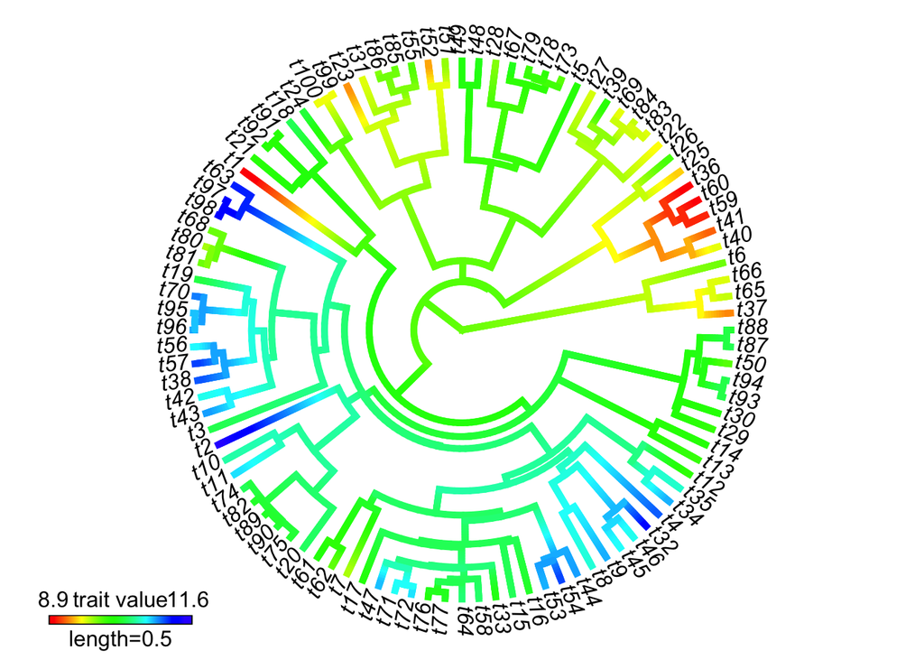

```r
# first we build our tree and simulate our true means
require(phytools)
set.seed(2)

# make trees
tree<-pbtree(n = 100, scale = 1)

# true species means
xbar<-fastBM(tree, sig2 = 0.5, a = 10)

# lets visualize this simulation
hist.true <- contMap(tree, x = xbar, outline = F,
                     lwd = 5, type = "fan",
                     fszie = c(.2, .1), sig = 1)
```

Now, we can generate vectors that contains sample species measurements. These measurements will be drawn from normal distributions with a standard deviation equal to 10% of the group mean. We will take a random number of samples ranging from 1-4 individuals for each species.

# Introduce measuremnt error

```r
x.10 <- vector()
# measurement error will be equal to 10% of the mean
sd <- .1 * mean(xbar)
for(i in 1:100){
   # number of samples in current taxa
   n <- sample(1:4, size = 1)
   # samples for current taxa
   y <- rnorm(n = n, mean = xbar[i], sd = sd)
   # tracking names
   names(y) <- rep(names(xbar)[i], length(y))
   # building up the new vector
   x.10 <- c(x.10, y)
}
# clean up
rm(i, n, sd, y, hist.true)
```

Lets plot our sampled data in comparison to our “true” data. To make sure we have some appreciation for what our simulations produced.

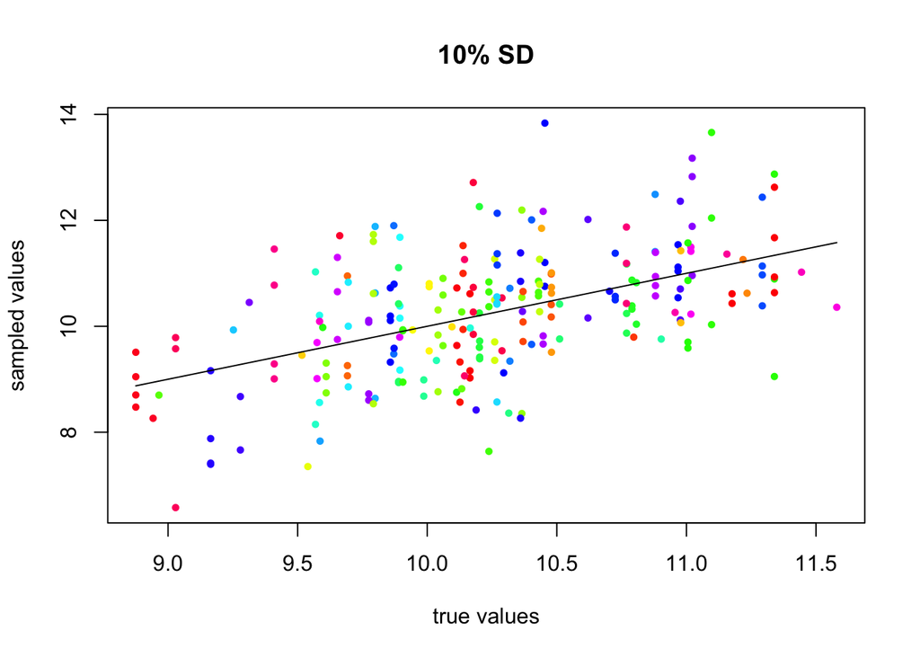

```r
y.10 <- x.10
tip.cols.10 <- vector(length = length(x.10))
rainbow <- sample(rainbow(100))
for(i in 1:length(x.10)){
  y.10[i] <- xbar[names(xbar) == names(x.10)[i]]
  tip.cols.10[i] <- rainbow[names(xbar) == names(x.10)[i]]
}
plot(y.10, x.10, col = tip.cols.10, pch = 16, cex = .75,
     ylab = "sampled values", xlab = "true values",
     main = "10% SD")
lines(xbar, xbar, col = "black")
```

```r
rm(y.10,tip.cols.10,rainbow,i)
```

It looks like our simulated data produced the type of results we expected.

# Fit models

```r
X.10 <- fitBayes(tree, x.10, ngen = 50000, model = "BM", method = "reduced")
```

```
## Control parameters (set by user or default):
```

```
## List of 8
##  $ sig2   : num 14.4
##  $ a      : num 10.2
##  $ xbar   : Named num [1:100] 9.93 10.57 9.98 10.09 9.38 ...
##   ..- attr(*, "names")= chr [1:100] "t37" "t65" "t66" "t6" ...
##  $ intV   : num 1.08
##  $ pr.mean: num [1:103] 1000 0 0 0 0 0 0 0 0 0 ...
##  $ pr.var : num [1:103] 1e+06 1e+03 1e+03 1e+03 1e+03 1e+03 1e+03 1e+03 1e+03 1e+03 ...
##  $ prop   : num [1:103] 0.144 0.144 0.144 0.144 0.144 ...
##  $ sample : num 100
```

```
## Starting MCMC...
```

```
## Done MCMC.
```

```r
X.10.f <- fitBayes(tree, x.10, ngen = 50000, model = "BM", method = "full")
```

```
## Control parameters (set by user or default):
```

```
## List of 8
##  $ sig2   : num 14.4
##  $ a      : num 10.2
##  $ xbar   : Named num [1:100] 9.93 10.57 9.98 10.09 9.38 ...
##   ..- attr(*, "names")= chr [1:100] "t37" "t65" "t66" "t6" ...
##  $ v      : Named num [1:100] 1.08 1.08 1.08 1.08 1.08 ...
##   ..- attr(*, "names")= chr [1:100] "t37" "t65" "t66" "t6" ...
##  $ pr.mean: num [1:202] 1000 0 0 0 0 0 0 0 0 0 ...
##  $ pr.var : num [1:202] 1e+06 1e+03 1e+03 1e+03 1e+03 1e+03 1e+03 1e+03 1e+03 1e+03 ...
##  $ prop   : Named num [1:202] 0.144 0.144 0.144 0.144 0.144 ...
##   ..- attr(*, "names")= chr [1:202] "" "" "" "" ...
##  $ sample : num 100
```

```
## Starting MCMC...
## Done MCMC.
```

```r
# This code was used to generate the results but we don't
# want to rerun each time since it takes a while.
X.10 <- fitBayes(tree, x.10, ngen = 4000000, model = "BM", method = "reduced")
X.10.f <- fitBayes(tree, x.10, ngen = 6000000, model = "BM", method = "full")
```

# MCMC evaluation

This provides us with a matrix (MCMC log file). If you are more comfortable in the tracer environment we can save it in a format compatible with this:

```r
write.table(X.10, file = "temp.log", row.names = F, sep = "\t")
write.table(X.10.f, file = "temp2.log", row.names = F, sep = "\t")
```

**show these in tracer**

# Evaluation of results

We can reproduce the figure from the paper showing that the Bayesian estimate of species means is better than a simple arithmetic mean of our samples for each species:

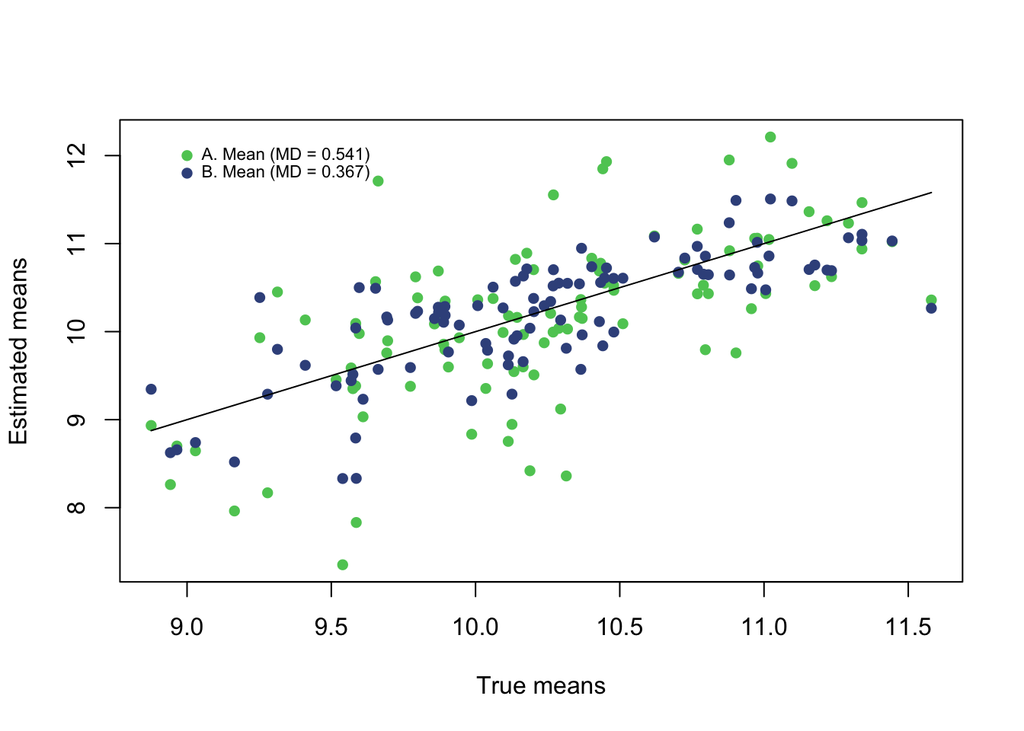

```r
library(viridis)
A.mean <- xbar
for(i in 1:length(A.mean)){
  A.mean[i] <- mean(x.10[names(xbar)[i] == names(x.10)])
}
B.mean <- colMeans(X.10[sample(300:500, 100), ])[names(xbar)]
plot(xbar, A.mean, ylab = "Estimated means", pch = 16,
     col = viridis(5)[4], xlab = "True means")
points(xbar, B.mean, pch = 16, col = viridis(5)[2])
lines(xbar, xbar, type = "l")
points(9, 12, pch = 16, col = viridis(5)[4])
text(9, 12, label = paste("A. Mean (MD = ",
                          round(mean(abs(xbar-A.mean)), 3),
                          ")", sep = ""), pos = 4, cex = .7)
points(9, 11.8, pch = 16, col = viridis(5)[2])
text(9, 11.8, label = paste("B. Mean (MD = ",
                            round(mean(abs(xbar - B.mean)), 3),
                            ")", sep = ""), pos = 4, cex = .7)
```

```r
rm(i)
```

# Full vs Reduced Model

**Reduced model:** This model seems appropriate when we expect our error to be due to random vagaries of our method that our uncorrelated with our traits under study. For instance just random noise of recording values off a continuous scale. Or perhaps if you have an army undergrads measuring a structure each person might have a bias of some sort in the way that they take the measurement.

**Full model:** This model seems appropriate when we have non-random differences in measurement error. One example of this would be if we have some level of precision say +/- 1 gram this will be low measurement error for large organism but high measurement error for a small organism.

# A case for the full model

**if you run the code below and analyze the mcmc log you will see that 6mil generations 20-30 minutes was insufficient to get a decent sample from the posterior. I’m not going to pursue it further at this point**

```r
#### 10% & 30% sd

# I did a little manual exploring to pick a subtree
# plot(tree, cex=.5)
# nodelabels(frame="none", cex=.5)
# we want all the tips that descend from node 106

noisy.tips <- tree$tip.label[phangorn::Descendants(tree, 106, type="tips")[[1]]]

x.10n <- x.10
sd <- .3 * mean(xbar)
for(i in 1:100){
  if(names(xbar[i]) %in% noisy.tips){
    # number of samples in current taxa
    n <- sum(names(xbar[i]) == names(x.10))
    # samples for current taxa
    y <- rnorm(n = n, mean = xbar[i], sd = sd)
    # tracking names
    names(y) <- rep(names(xbar)[i], length(y))
    # building up the new vector
    spot <- which(names(xbar[i]) == names(x.10))[1]
    x.10n[spot:(spot+n-1)] <- y
  }
}
# clean up

rm(i,n,sd,y, spot)

# we won't run this because it takes too long
# X.10.f<-fitBayes(tree, x.10n, ngen = 6000000, model = "BM", method = "full")
# write.table(X.10.f, file="noisy.log", row.names=F, sep="\t")
```

# Fewer samples

So finally we might imagine having a dataset where we have only a single value for each species and yet we believe that we should account for an inherent uncertainty in our tip values. So lets try that:

```r
X.single<-try(fitBayes(tree, xbar, ngen = 6000000,
                 model = "BM", method = "reduced"))
```

```
## List of 8
##  $ sig2   : num 0.531
##  $ a      : num 10.2
##  $ xbar   : Named num [1:100] 9.25 9.65 9.6 9.86 9.58 ...
##   ..- attr(*, "names")= chr [1:100] "t37" "t65" "t66" "t6" ...
##  $ intV   : num NaN
##  $ pr.mean: num [1:103] 1000 0 0 0 0 0 0 0 0 0 ...
##  $ pr.var : num [1:103] 1e+06 1e+03 1e+03 1e+03 1e+03 1e+03 1e+03 1e+03 1e+03 1e+03 ...
##  $ prop   : num [1:103] 0.00531 0.00531 0.00531 0.00531 0.00531 ...
##  $ sample : num 100
```

This doesn’t work. But, if we have even a single species for which we have a repeated measure we can run the function as we did above:

```r
# duplicate value for first species
xfoo <- xbar[c(1,1:100)]
X.single<-fitBayes(tree, xfoo, ngen = 60000,
                 model = "BM", method = "reduced")
```

```
## Control parameters (set by user or default):
```

```
## List of 8
##  $ sig2   : num 0.531
##  $ a      : num 10.2
##  $ xbar   : Named num [1:100] 9.25 9.65 9.6 9.86 9.58 ...
##   ..- attr(*, "names")= chr [1:100] "t37" "t65" "t66" "t6" ...
##  $ intV   : num 0
##  $ pr.mean: num [1:103] 1000 0 0 0 0 0 0 0 0 0 ...
##  $ pr.var : num [1:103] 1e+06 1e+03 1e+03 1e+03 1e+03 1e+03 1e+03 1e+03 1e+03 1e+03 ...
##  $ prop   : num [1:103] 0.00531 0.00531 0.00531 0.00531 0.00531 ...
##  $ sample : num 100
```

```
## Starting MCMC...
```

```
## Done MCMC.
```